# Coursework1_sample_final

## Example Coursework 1

## IMPORTANT ## - Once you have finished, save your workbook with your student number at the end of the file name, and please save this file as a .html using file -> save and export notebook as -> html

Additionally - please enter your student number in the box below:

Student number: 121344

## Context

Imagine you are involved in running a clinical trial measuring the effect of a new drug in three different treatment groups: Placebo, Low Dose, and High Dose on patients’ cholesterol levels.

For each patient, you have recorded:

- **SubjectID**: Unique participant identifier
- **TreatmentGroup**: Placebo, LowDose, or HighDose
- **Age**: Patient’s age
- **Gender**: M or F
- **BMI**: Body Mass Index
- **CholesterolPre**: Patient’s cholesterol level before the trial
- **CholesterolPost**: Patient’s cholesterol level after the trial
- **SideEffectsScale**: A subjective scale (1-10) indicating the severity of side effects, with 1 = no side effects and 10 = severe side effects

The overall goal of the trial is to see if the drugs lower cholesterol in patients, and whether there are any significant side effects.

# This is a sample coursework - model text answers are shown in red

# Section 1: Load the dataframe into python using pandas.

Tasks:

- Look at the data
- Load the data into python
- Calculate some metrics (mean of columns, std of columns etc.) for the data

Questions:

1. Are there any missing values in the data? How would you recommend handling missing data in the event there is any? (10% of the marks)
2. What can you see from the metrics you have calculated? (10% of the marks)

## Answer:

```python
import pandas as pd
```

```python
df = pd.read_csv("./clinical_trial_data.csv")

df.head()
```

|  | SubjectID | TreatmentGroup | Age | Gender | BMI | CholesterolPre | CholesterolPost | SideEffectsScale |
| --- | --- | --- | --- | --- | --- | --- | --- | --- |
| 0 | 1 | Placebo | 45 | M | 21.3 | 225 | 219.0 | 1 |
| 1 | 2 | HighDose | 62 | F | 28.1 | 218 | 193.0 | 4 |
| 2 | 3 | LowDose | 43 | M | 28.7 | 227 | 205.0 | 5 |
| 3 | 4 | HighDose | 62 | M | 29.9 | 246 | 210.0 | 5 |
| 4 | 5 | Placebo | 50 | F | 29.2 | 216 | 208.0 | 2 |

```python
df.info()
```

```
<class 'pandas.core.frame.DataFrame'>
RangeIndex: 210 entries, 0 to 209
Data columns (total 8 columns):
 #   Column            Non-Null Count  Dtype
---  ------            --------------  -----
 0   SubjectID         210 non-null    int64
 1   TreatmentGroup    210 non-null    object
 2   Age               210 non-null    int64
 3   Gender            210 non-null    object
 4   BMI               210 non-null    float64
 5   CholesterolPre    210 non-null    int64
 6   CholesterolPost   205 non-null    float64
 7   SideEffectsScale  210 non-null    int64
dtypes: float64(2), int64(4), object(2)
memory usage: 13.3+ KB
```

```python
df_clean = df.dropna()
```

```python
df_clean.describe()
```

|  | SubjectID | Age | BMI | CholesterolPre | CholesterolPost | SideEffectsScale |
| --- | --- | --- | --- | --- | --- | --- |
| count | 205.000000 | 205.000000 | 205.000000 | 205.000000 | 205.000000 | 205.000000 |
| mean | 104.239024 | 52.541463 | 26.963415 | 224.312195 | 207.102439 | 3.624390 |
| std | 60.494016 | 8.136970 | 3.064067 | 19.904431 | 20.963653 | 1.904687 |
| min | 1.000000 | 40.000000 | 18.800000 | 190.000000 | 162.000000 | 1.000000 |
| 25% | 52.000000 | 45.000000 | 25.200000 | 209.000000 | 195.000000 | 2.000000 |
| 50% | 104.000000 | 54.000000 | 27.000000 | 225.000000 | 206.000000 | 3.000000 |
| 75% | 155.000000 | 60.000000 | 29.100000 | 241.000000 | 222.000000 | 5.000000 |
| max | 209.000000 | 65.000000 | 35.400000 | 260.000000 | 253.000000 | 8.000000 |

# Text Answers:

### Question 2

Looking at the mean of the CholesterolPre and CholsterolPost columns, the CholesterolPre seems quite a bit higher than the CholesterolPost - suggesting already that there might be a significant difference. Mean age in the study is ~50, and average BMI is 27. The average side effect levels are 3.6 on a scale of 1-10.

## Section 2: Plotting the data

Tasks:

- Plot the distributions of the CholesterolPre and CholesterolPost columns
- Plot the effects of the treatment on the post study cholesterol
- Plot the side effects by group in the study

Questions:

3. What do the distributions of cholesterol show? What does this mean for applying statistical tests? (10% of the marks)
4. Does the treatment appear to be working? What does the data show for treatment effect and side effects? (10% of the marks)

## Answer:

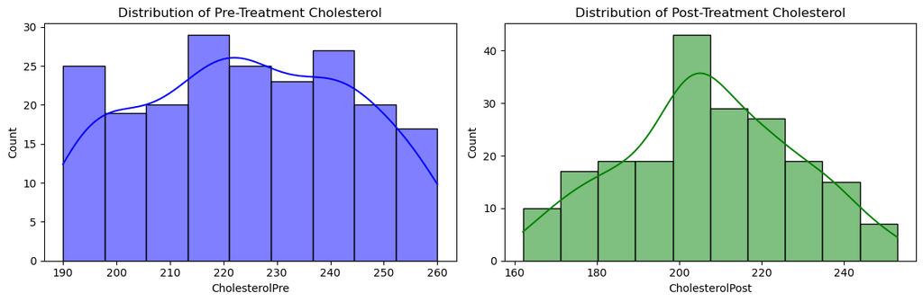

```python
import matplotlib.pyplot as plt
import seaborn as sns

plt.figure(figsize=(12, 4))

plt.subplot(1, 2, 1)
sns.histplot(df_clean["CholesterolPre"], kde=True, color="blue")
plt.title("Distribution of Pre-Treatment Cholesterol")

plt.subplot(1, 2, 2)
sns.histplot(df_clean["CholesterolPost"], kde=True, color="green")
plt.title("Distribution of Post-Treatment Cholesterol")

plt.tight_layout()
plt.show()
```

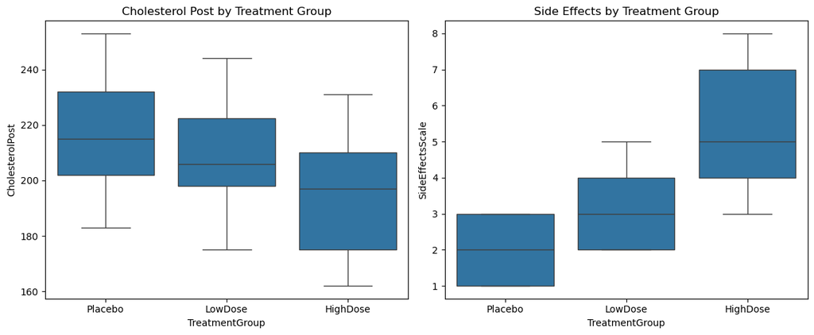

```python
plt.figure(figsize=(12, 5))
plt.subplot(1, 2, 1)
sns.boxplot(x="TreatmentGroup", y="CholesterolPost", data=df_clean, order= ["Placebo", "LowDose", "HighDose"])
plt.title("Cholesterol Post by Treatment Group")

plt.subplot(1, 2, 2)
sns.boxplot(x="TreatmentGroup", y="SideEffectsScale", data=df_clean, order= ["Placebo", "LowDose", "HighDose"])
plt.title("Side Effects by Treatment Group")

plt.tight_layout()
plt.show()
```

```python
group_means_chol = df_clean.groupby("TreatmentGroup")["CholesterolPost"].mean()
group_means_side = df_clean.groupby("TreatmentGroup")["SideEffectsScale"].mean()
print("\nAverage CholesterolPost by Group:\n", group_means_chol)
print("\nAverage SideEffectsScale by Group:\n", group_means_side)
```

```
Average CholesterolPost by Group:
 TreatmentGroup
HighDose    194.753623
LowDose     209.059701
Placebo     217.550725
Name: CholesterolPost, dtype: float64

Average SideEffectsScale by Group:
 TreatmentGroup
HighDose    5.536232
LowDose     3.388060
Placebo     1.942029
Name: SideEffectsScale, dtype: float64
```

# Text Answers:

### Question 3

The distributions of cholesterol seem to be fairly normally distributed, this means that parametric tests are probably the most reasonable ones to apply in future steps.

### Question 4

The treatment does appear to be working as the post treatment cholesterol seems lower in the high treatment group compared to the low and placebo groups. Side effects appear to be increased a lot though - with the mean side effects for the high treatment group being 5.5 out of 10.

## Section 3: Statistical tests

Tasks:

- Perform an ANOVA for the cholesterol levels of the treatment groups post treatment
- Perform an analysis of the correlation between age and colesterol levels.

Questions (explain your answers):

5. Are any differences in the cholesterol levels post treatment significant? (10% of the marks)
6. Is there a correlation between the age of the patients and their cholesterol pre or post treatment? 10% of the marks)

## Answer:

```python
from scipy import stats

# Group the patients into each treatment group and get their cholesterol levels
placebo_chol = df_clean.loc[df_clean["TreatmentGroup"] == "Placebo", "CholesterolPost"]
lowdose_chol = df_clean.loc[df_clean["TreatmentGroup"] == "LowDose", "CholesterolPost"]
highdose_chol = df_clean.loc[df_clean["TreatmentGroup"] == "HighDose", "CholesterolPost"]

# ANOVA across all three treatment groups
f_stat, p_val = stats.f_oneway(placebo_chol, lowdose_chol, highdose_chol)
print("\nANOVA for CholesterolPost:")
print("F-Statistic:", f_stat, "   P-value:", p_val)
```

```
ANOVA for CholesterolPost:
F-Statistic: 25.923589929057762    P-value: 9.52098056085556e-11
```

```python
# Since the ANOVA is significant we will perform a Tukey post-hoc

posthoc = stats.tukey_hsd(placebo_chol, lowdose_chol, highdose_chol)
print(posthoc)
```

```
Tukey's HSD Pairwise Group Comparisons (95.0% Confidence Interval)
Comparison  Statistic  p-value  Lower CI  Upper CI
 (0 - 1)      8.491     0.025     0.880    16.102
 (0 - 2)     22.797     0.000    15.243    30.352
 (1 - 0)     -8.491     0.025   -16.102    -0.880
 (1 - 2)     14.306     0.000     6.695    21.917
 (2 - 0)    -22.797     0.000   -30.352   -15.243
 (2 - 1)    -14.306     0.000   -21.917    -6.695
```

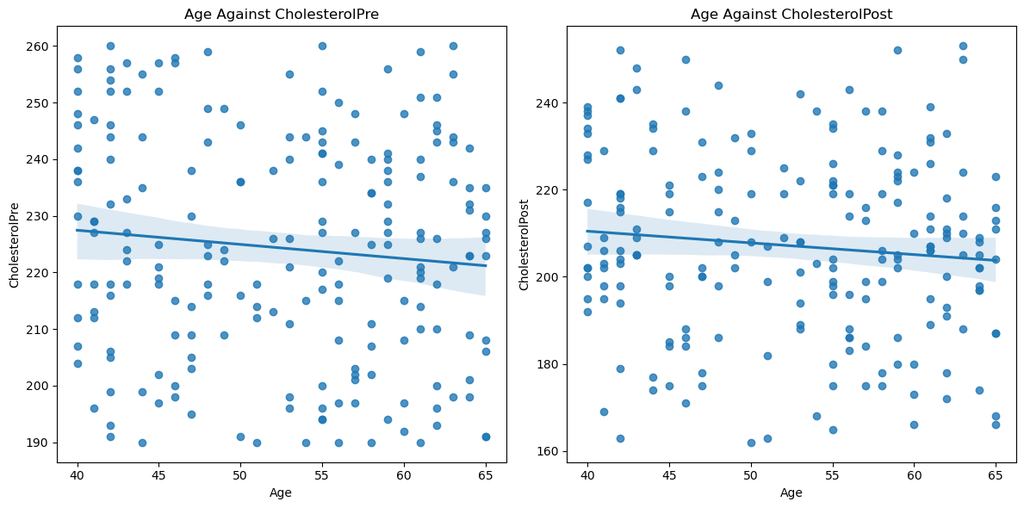

```python
plt.figure(figsize=(12, 6))
plt.subplot(1, 2, 1)
sns.regplot(x="Age", y="CholesterolPre", data=df_clean)
plt.title("Age Against CholesterolPre")

plt.subplot(1, 2, 2)
sns.regplot(x="Age", y="CholesterolPost", data=df_clean)
plt.title("Age Against CholesterolPost")

plt.tight_layout()
plt.show()
```

```python
# The plots dont look significant but we should calculate p-values to make sure

print("Pre Study Cholesterol:Age correlation:", stats.pearsonr(df_clean["Age"], df_clean["CholesterolPre"]))

print("Post Study Cholesterol:Age correlation:", stats.pearsonr(df_clean["Age"], df_clean["CholesterolPost"]))
```

```
Pre Study Cholesterol:Age correlation: PearsonRResult(statistic=-0.10241020874985352, pvalue=0.1439689204437973)
Post Study Cholesterol:Age correlation: PearsonRResult(statistic=-0.10426818286480666, pvalue=0.1367975967047224)
```

# Text Answers:

### Question 5

All differences in the cholesterol post treatment are significant - the ANOVA showed a significant difference, and the tukey post-hoc showed that all differences are statistically significant in our group. I chose ANOVA because the data is normally distributed

### Question 6

We see no correlation between age and cholesterol levels as calculated via a pearson rho correlation - chosen because the data is normally distributed.

## Section 4: Unsupervised Learning

Tasks:

- Perform PCA on the numeric columns from the dataframe
- Plot the PCA with the treatment groups coloured differently
- Perform clustering analysis
- Plot the results of the clustering analysis

Questions:

7. What does the PCA show? (10% of the marks)
8. How does your clustering analysis compare to the treatment groups? (10% of the marks)

## Answer:

```python
# We need to first get the numeric data and scale it
from sklearn.preprocessing import StandardScaler

df_numeric = df_clean.select_dtypes('number')

scaler = StandardScaler()
df_scaled = pd.DataFrame(scaler.fit_transform(df_numeric))
```

```python
df_scaled.head()
```

|  | 0 | 1 | 2 | 3 | 4 | 5 |
| --- | --- | --- | --- | --- | --- | --- |
| 0 | -1.710777 | -0.929084 | -1.852857 | 0.034640 | 0.568922 | -1.381232 |
| 1 | -1.694206 | 1.165261 | 0.371848 | -0.317901 | -0.674356 | 0.197686 |
| 2 | -1.677635 | -1.175477 | 0.568146 | 0.135366 | -0.100535 | 0.723991 |
| 3 | -1.661064 | 1.165261 | 0.960741 | 1.092264 | 0.138557 | 0.723991 |
| 4 | -1.644493 | -0.313100 | 0.731727 | -0.418628 | 0.042920 | -0.854926 |

```python
from sklearn.decomposition import PCA

# Define PCA model to keep 2 principal components
pca = PCA(n_components=2)

# Fit PCA on the scaled data and transform
pca_result = pca.fit_transform(df_scaled)

# Add the principal components to the original dataframe
df_clean["PCA1"] = pca_result[:, 0]
df_clean["PCA2"] = pca_result[:, 1]

# Display explained variance
print("\nExplained Variance by Components:", pca.explained_variance_ratio_)
```

```
Explained Variance by Components: [0.33182925 0.1879198 ]
```

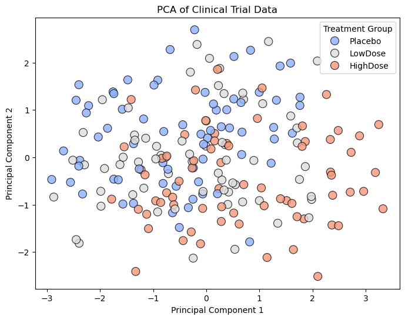

```python
plt.figure(figsize=(8,6))
sns.scatterplot(x="PCA1", y="PCA2", hue="TreatmentGroup", data = df_clean, palette="coolwarm"
                , alpha=0.8, hue_order = ["Placebo", "LowDose", "HighDose"], s = 100, edgecolor = "k")
plt.title("PCA of Clinical Trial Data")
plt.xlabel("Principal Component 1")
plt.ylabel("Principal Component 2")
plt.legend(title="Treatment Group")
plt.show()
```

```python
from sklearn.cluster import KMeans

# Fit k-means with 3 clusters (matching Treatment Groups)
kmeans = KMeans(n_clusters=3, random_state=42)
df_clean["Cluster"] = kmeans.fit_predict(pca_result)
```

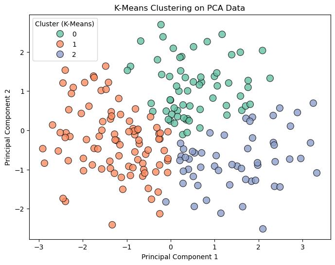

```python
# Compare Clustering to TreatmentGroup
plt.figure(figsize=(8,6))
sns.scatterplot(x="PCA1", y="PCA2", hue="Cluster", data = df_clean, palette="Set2"
                , alpha=0.8, s = 100, edgecolor = "k")

plt.title("K-Means Clustering on PCA Data")
plt.xlabel("Principal Component 1")
plt.ylabel("Principal Component 2")
plt.legend(title="Cluster (K-Means)")
plt.show()
```

# Text Answers:

### Question 7

PCA doesnt show any distinctive groups, but when colouring by treatment regime, the patients on the right hand side seem to be more likely to be in the high dose treatment group

### Question 8

The clustering analysis seems to have identified 3 groups, split into a left, top, and right group. The rightmost group has a strong overlap with the high dose patients.

## Section 5: Summary

Question 9: Having performed your analysis of the data, you should now have a reasonable idea of the findings, limitations, and overall conclusions. Write a short (~5 sentance) summary of the results of the study, including statistical findings, and what this means for the drug being tested. (20% of the marks)

# Text Answers: